# HW3

Author

Yufan Li

## Homework 3

Github Repo Link: https://github.com/YufanLi2002/STATS506.git

### Problem 1 - Vision

**a. Download the file VIX_D from [this location](http://wwwn.cdc.gov/nchs/nhanes/search/datapage.aspx?Component=Examination&CycleBeginYear=2005), and determine how to read it into R. Then download the file DEMO_D from [this location](http://wwwn.cdc.gov/Nchs/Nhanes/Search/DataPage.aspx?Component=Demographics&CycleBeginYear=2005). Note that each page contains a link to a documentation file for that data set. Merge the two files to create a single `data.frame`, using the SEQN variable for merging. Keep only records which matched. Print out your total sample size, showing that it is now 6,980.**

```r
setwd("~/Documents/GitHub/STATS506/HW3")
# Load necessary libraries
library(haven)
library(knitr)
library(stargazer)
library(kableExtra)
library(broom)
library(dplyr)
# Read the VIX_D and DEMO_D files
vix_d <- read_xpt("VIX_D.XPT")
demo_d <- read_xpt("DEMO_D.XPT")
## merge the two data sets using the SEQN variable
merged_data <- merge(vix_d, demo_d, by = "SEQN")
## Print the total sample size
nrow(merged_data)
```

```
[1] 6980
```

```r
#merged_data
```

**b. Without fitting any models, estimate the proportion of respondents within each 10-year age bracket (e.g. 0-9, 10-19, 20-29, etc) who wear glasses/contact lenses for distance vision. Produce a nice table with the results.**

```r
# Create age brackets by cutting the continuous age variable (RIDAGEYR) into intervals
merged_data <- merged_data %>%
  mutate(age_bracket = cut(RIDAGEYR,
                           breaks = seq(0, 100, by = 10),  # Break the age into 10-year intervals
                           right = FALSE,
                           # Include the left boundary but not the right one (e.g., [0,10) )
                           labels = paste(seq(0, 90, by = 10), seq(9, 99, by = 10), sep = "-")))
                           # Label the age brackets (e.g., "0-9", "10-19")

# Calculate the proportion of respondents who wear glasses/contact lenses in each age bracket
result <- merged_data %>%
  filter(!is.na(VIQ220)) %>%
  # Filter out rows where the glasses/contact lenses variable (VIQ220) is missing
  group_by(age_bracket) %>%   # Group data by the newly created age brackets
  summarise(total_respondents = n(),
            # Count the total number of respondents in each age bracket
            glasses_wearers = sum(VIQ220 == 1, na.rm = TRUE),
            # Count the number of people who wear glasses/contact lenses (VIQ220 == 1)
            proportion = round(glasses_wearers / total_respondents, 3)) %>%
  # Calculate the proportion of glasses wearers in each bracket, rounded to 3 decimal places
  ungroup()  # Ungroup the data to remove the grouping structure

# Generate a clean HTML table with kable, showing the proportion of glasses/contact lenses
# wearers by age bracket
kable(result, format = "html",
      caption = "Proportion of Respondents Wearing Glasses/Contact Lenses by Age Bracket") %>%
  kable_styling(full_width = F)  # Style the table to avoid full width display, making it look nicer
```

Proportion of Respondents Wearing Glasses/Contact Lenses by Age Bracket

| age_bracket | total_respondents | glasses_wearers | proportion |
| --- | --- | --- | --- |
| 10-19 | 2088 | 670 | 0.321 |
| 20-29 | 939 | 306 | 0.326 |
| 30-39 | 750 | 269 | 0.359 |
| 40-49 | 773 | 286 | 0.370 |
| 50-59 | 609 | 335 | 0.550 |
| 60-69 | 630 | 392 | 0.622 |
| 70-79 | 447 | 299 | 0.669 |
| 80-89 | 311 | 208 | 0.669 |

**c. Fit three logistic regression models predicting whether a respondent wears glasses/contact lenses for distance vision. Predictors:**

1. **age**
2. **age, race, gender**
3. **age, race, gender, Poverty Income ratio**

**Produce a table presenting the estimated odds ratios for the coefficients in each model, along with the sample size for the model, the pseudo-**R2**, and AIC values.**

```r
# Assuming merged_data is your dataset
# Recode VIQ220 to a binary variable
merged_data <- merged_data %>%
  mutate(VIQ220 = case_when(
    VIQ220 == 1 ~ 1,   # Yes
    VIQ220 == 2 ~ 0,   # No
    TRUE ~ NA_real_    # Recode Don't know and Missing to NA
  ))

# Fit the first model: Age as the predictor
model1 <- glm(VIQ220 ~ RIDAGEYR,
               data = merged_data,
               family = binomial(link = "logit"))

# Fit the second model: Age, Race, Gender as predictors
model2 <- glm(VIQ220 ~ RIDAGEYR + RIDRETH1 + RIAGENDR,
               data = merged_data,
               family = binomial(link = "logit"))

# Fit the third model: Age, Race, Gender, Poverty Income Ratio as predictors
model3 <- glm(VIQ220 ~ RIDAGEYR + RIDRETH1 + RIAGENDR + INDFMPIR,
               data = merged_data,
               family = binomial(link = "logit"))
```

```r
#' Extract Summary Statistics from Logistic Regression Model
#'
#' This function takes a fitted logistic regression model and extracts
#' the estimated odds ratios, sample size, pseudo R², and AIC value.
#'
#' @param model A fitted glm model object (of class "glm") with a binomial family.
#'
#' @return A list containing:
#' \item{tidy_model}{A data frame with the terms and their estimated odds ratios.}
#' \item{sample_size}{The number of observations used in the model.}
#' \item{pseudo_r2}{The pseudo R² value for the model.}
#' \item{aic_value}{The AIC value for the model.}
#'
#' @examples
#' # Fit a logistic regression model
#' model <- glm(VIQ220 ~ RIDAGEYR + RIDRETH1 + RIAGENDR + INDFMPIR,
#'              data = merged_data,
#'              family = binomial)
#'
#' # Extract the model summary
#' model_summary <- get_model_summary(model)
#'
#' @export
get_model_summary <- function(model) {
  # Get additional model statistics
  odds_ratios <- exp(coef(model))    # Extract odds ratio
  sample_size <- nobs(model)                             # Extract sample size
  pseudo_r2 <- 1 - (model$deviance / model$null.deviance)  # Calculate pseudo R²
  aic_value <- AIC(model)                              # Calculate AIC

  return(list(odds_ratios = odds_ratios,
              sample_size = sample_size,
              pseudo_r2 = pseudo_r2,
              aic_value = aic_value))
} # return a list of desired statistics
```

```r
# Prepare odds ratios for each model as a data frame
model1_summary <- get_model_summary(model1)
model2_summary <- get_model_summary(model2)
model3_summary <- get_model_summary(model3)

# Create a data frame for odds ratios
odds_ratios_df <- bind_rows(
  data.frame(Model = "Model 1 (Age)",
             Predictor = names(model1_summary$odds_ratios),
             Odds_Ratio = model1_summary$odds_ratios),
  data.frame(Model = "Model 2 (Age, Race, Gender)",
             Predictor = names(model2_summary$odds_ratios),
             Odds_Ratio = model2_summary$odds_ratios),
  data.frame(Model = "Model 3 (Age, Race, Gender, Poverty Income Ratio)",
             Predictor = names(model3_summary$odds_ratios),
             Odds_Ratio = model3_summary$odds_ratios)
)

# Create a data frame for model statistics (sample size, pseudo R², AIC)
model_stats <- data.frame(
  Model = c("Model 1 (Age)", "Model 2 (Age, Race, Gender)",
            "Model 3 (Age, Race, Gender, Poverty Income Ratio)"),
  Sample_Size = c(model1_summary$sample_size, model2_summary$sample_size,
                  model3_summary$sample_size),
  Pseudo_R2 = c(model1_summary$pseudo_r2, model2_summary$pseudo_r2,
                model3_summary$pseudo_r2),
  AIC = c(model1_summary$aic_value, model2_summary$aic_value,
          model3_summary$aic_value)
)

# Merge the two tables (odds ratios and model statistics)
final_table <- left_join(odds_ratios_df, model_stats, by = "Model")

# Create a kable table
kable(final_table,
      caption = "Estimated Odds Ratios for Models Predicting Glasses/Contact Lenses Use",
      col.names = c("Model", "Predictor", "Odds Ratio", "Sample Size", "Pseudo R²", "AIC"),
      format = "html",
      digits = 3)
```

Estimated Odds Ratios for Models Predicting Glasses/Contact Lenses Use

| Model | Predictor | Odds Ratio | Sample Size | Pseudo R² | AIC |
| --- | --- | --- | --- | --- | --- |
| Model 1 (Age) | (Intercept) | 0.283 | 6545 | 0.050 | 8475.887 |
| Model 1 (Age) | RIDAGEYR | 1.025 | 6545 | 0.050 | 8475.887 |
| Model 2 (Age, Race, Gender) | (Intercept) | 0.092 | 6545 | 0.063 | 8358.496 |
| Model 2 (Age, Race, Gender) | RIDAGEYR | 1.025 | 6545 | 0.063 | 8358.496 |
| Model 2 (Age, Race, Gender) | RIDRETH1 | 1.133 | 6545 | 0.063 | 8358.496 |
| Model 2 (Age, Race, Gender) | RIAGENDR | 1.646 | 6545 | 0.063 | 8358.496 |
| Model 3 (Age, Race, Gender, Poverty Income Ratio) | (Intercept) | 0.072 | 6247 | 0.069 | 7940.790 |
| Model 3 (Age, Race, Gender, Poverty Income Ratio) | RIDAGEYR | 1.024 | 6247 | 0.069 | 7940.790 |
| Model 3 (Age, Race, Gender, Poverty Income Ratio) | RIDRETH1 | 1.097 | 6247 | 0.069 | 7940.790 |
| Model 3 (Age, Race, Gender, Poverty Income Ratio) | RIAGENDR | 1.680 | 6247 | 0.069 | 7940.790 |
| Model 3 (Age, Race, Gender, Poverty Income Ratio) | INDFMPIR | 1.153 | 6247 | 0.069 | 7940.790 |

**d. From the third model from the previous part, test whether the *odds* of men and women being wears of glasess/contact lenses for distance vision differs. Test whether the *proportion* of wearers of glasses/contact lenses for distance vision differs between men and women. Include the results of the each test and their interpretation.**

```r
# Summary of the model3 for test whether the odds of men and women being wears of
# glasess/contact lenses for distance vision differs.
summary(model3)
```

```
Call:
glm(formula = VIQ220 ~ RIDAGEYR + RIDRETH1 + RIAGENDR + INDFMPIR,
    family = binomial(link = "logit"), data = merged_data)

Coefficients:
             Estimate Std. Error z value Pr(>|z|)
(Intercept) -2.634169   0.128457 -20.506  < 2e-16 ***
RIDAGEYR     0.023763   0.001262  18.829  < 2e-16 ***
RIDRETH1     0.092776   0.023564   3.937 8.24e-05 ***
RIAGENDR     0.518595   0.054121   9.582  < 2e-16 ***
INDFMPIR     0.142601   0.017011   8.383  < 2e-16 ***
---
Signif. codes:  0 '***' 0.001 '**' 0.01 '*' 0.05 '.' 0.1 ' ' 1

(Dispersion parameter for binomial family taken to be 1)

    Null deviance: 8519.1  on 6246  degrees of freedom
Residual deviance: 7930.8  on 6242  degrees of freedom
  (733 observations deleted due to missingness)
AIC: 7940.8

Number of Fisher Scoring iterations: 4
```

```r
## Compute the odds ratio
exp(coef(model3)["RIAGENDR"])
```

```
RIAGENDR
1.679667
```

```r
## Compute the CI for odds ratio
exp(confint(model3)["RIAGENDR", ])
```

```
   2.5 %   97.5 %
1.510878 1.867983
```

Based on the odds ratio of gender being 1.679667 (which is significantly different from 1), and the 95% confidence interval of odds ratio does not include 1. We can conclude that the odds of wearing glasses/contact lenses differs between gender.

In addition, based on the summary output of model3, we can also see that the p-value for the gender coefficient is <2e-16 which is less than alpha level of 0.05. Therefore, we reject the null hypothesis that the odds of wearing glasses/contact lenses are the same for men and women, and conclude that the odds of wearing glasses/contact lenses differs between gender.

```r
# Load the emmeans package
library(emmeans)

# Get estimated marginal means for gender
em_gender <- emmeans(model3, ~ RIAGENDR, type = "response")

# Print the marginal means (proportions) for men and women
print(em_gender)
```

```
 RIAGENDR  prob      SE  df asymp.LCL asymp.UCL
        1 0.356 0.00903 Inf     0.338     0.373
        2 0.481 0.00923 Inf     0.463     0.499

Confidence level used: 0.95
Intervals are back-transformed from the logit scale
```

```r
# Test for a difference in proportions between men and women
contrast(em_gender, method = "pairwise")
```

```
 contrast              odds.ratio     SE  df null z.ratio p.value
 RIAGENDR1 / RIAGENDR2      0.595 0.0322 Inf    1  -9.582  <.0001

Tests are performed on the log odds ratio scale
```

Based on the output of the proportion test, we can see that the p-value is less than 0.0001 which is smaller than the alpha of 0.05. and the 95% CI for both genders do not overlap. Therefore, we can conclude that the proportion of wearers of glasses/contact lenses for distance vision differs between men and women.

## **Problem 2 - Sakila**

**Load the “sakila” database discussed in class into SQLite. It can be downloaded from https://github.com/bradleygrant/sakila-sqlite3.**

**For these problems, do not use any of the tables whose names end in `_list`.**

**a. What year is the oldest movie from, and how many movies were released in that year? Answer this with a single SQL query.**

**For each of the following questions, solve them in two ways: First, use SQL query or queries to extract the appropriate table(s), then use regular R operations on those `data.frame`s to answer the question. Second, use a single SQL query to answer the question.**

```r
# Load the DBI and RSQLite libraries
library(DBI)
library(RSQLite)
library(dplyr)

## establish connection
sakila <- dbConnect(SQLite(), "/Users/yufan/Documents/GitHub/STATS506/HW3/sakila_master.db")
#dbListTables(sakila)

## FIRST WAY
# Extract release_year from the film table
film_data <- dbGetQuery(sakila, "SELECT release_year FROM film")

# Find the oldest year
oldest <- min(film_data$release_year, na.rm = TRUE)
oldest
```

```
[1] "2006"
```

```r
# Count how many movies were released in that year
movies <- sum(film_data$release_year == oldest, na.rm = TRUE)
movies
```

```
[1] 1000
```

```r
## SECOND WAY
## Single SQL Query to get the oldest year and the number of movies released that year
result <- dbGetQuery(sakila, "
    SELECT release_year, COUNT(*) AS movie_count
    -- Select the release year and count the number of movies
    FROM film
    -- Specify the film table
    WHERE release_year = (SELECT MIN(release_year) FROM film)
    -- Filter for the minimum release year
    GROUP BY release_year
    -- Group results by release year to get the count
")

# Print the result of the query
print(result)  # Display the release year along with the count of movies released in that year
```

```
  release_year movie_count
1         2006        1000
```

The oldest movie comes from 2006, and 1000 movies were released in that year.

**b. What genre of movie is the least common in the data, and how many movies are of this genre?**

```r
### FIRST WAY
# Query to select all rows from the category table
category <- dbGetQuery(sakila, "SELECT * FROM category")
head(category)
```

```
  category_id        name         last_update
1           1      Action 2020-12-23 07:12:31
2           2   Animation 2020-12-23 07:12:31
3           3    Children 2020-12-23 07:12:31
4           4    Classics 2020-12-23 07:12:31
5           5      Comedy 2020-12-23 07:12:31
6           6 Documentary 2020-12-23 07:12:31
```

```r
# Query to select all rows from the film_category table
film_category <- dbGetQuery(sakila, "SELECT * FROM film_category")
head(film_category)
```

```
  film_id category_id         last_update
1       1           6 2020-12-23 07:14:58
2       2          11 2020-12-23 07:14:58
3       3           6 2020-12-23 07:14:58
4       4          11 2020-12-23 07:14:58
5       5           8 2020-12-23 07:14:58
6       6           9 2020-12-23 07:14:58
```

```r
# Merge the data frames based on category_id
new_data <- merge(film_category, category, by = "category_id")

# Count the number of films per genre
genre_counts <- table(new_data$name)

# Find the genre with the least movies
least_common_genre <- names(genre_counts)[which.min(genre_counts)]
least_common_count <- min(genre_counts)

# Print the result
least_common_genre
```

```
[1] "Music"
```

```r
least_common_count
```

```
[1] 51
```

```r
### SECOND WAY
# Execute the SQL query to find the least common genre of movies
least_common_genre <- dbGetQuery(sakila, "
  SELECT c.name AS genre,              --Select the genre name and count of films
  COUNT(fc.film_id) AS movie_count
  FROM film_category fc                --Specify the film_category table with alias 'fc'
  JOIN category c ON fc.category_id = c.category_id
                                      --Join film_category with category table on category_id
  GROUP BY c.name                     --Group the results by genre name
  ORDER BY movie_count ASC            --Order results by the count of films in ascending order
  LIMIT 1;                            --Limit the output to the least common genre
")
# Display the result of the query
print(least_common_genre)
```

```
  genre movie_count
1 Music          51
```

The “Music” genre of movie is the least common in the data, and 51 movies are of this genre.

**c. Identify which country or countries have exactly 13 customers.**

```r
## FIRST WAY
# Extract relevant data using SQL to get customer and address information

customer_data <- dbGetQuery(sakila, "
    SELECT c.customer_id,                       -- Get customer ID
           co.country_id,                       -- Get country ID
           co.country AS country_name           -- Get country name
    FROM customer c                             -- From customer table (aliased as 'c')
    JOIN address a ON c.address_id = a.address_id  -- Join with address table on address ID
    JOIN city ci ON a.city_id = ci.city_id     -- Join with city table on city ID
    JOIN country co ON ci.country_id = co.country_id  -- Join with country table on country ID
")

# Count the number of customers per country
customers_per_country <- customer_data %>%
    group_by(country_id, country_name)%>%     # Group data by country_id
    summarise(customer_count = n()) %>%       # Summarise to count the number of customers
    filter(customer_count == 13)              # Filter for countries with exactly 13 customers
# Display the result of countries with exactly 13 customers
print(customers_per_country)
```

```
# A tibble: 2 × 3
# Groups:   country_id [2]
  country_id country_name customer_count
       <int> <chr>                 <int>
1          6 Argentina                13
2         69 Nigeria                  13
```

```r
## SECOND WAY
# Execute a single SQL query to find countries with exactly 13 customers
countries <- dbGetQuery(sakila, "
    SELECT co.country_id,                             -- Select country_id
           co.country AS country_name,               -- Select country name (renamed for clarity)
           COUNT(c.customer_id) AS customer_count     -- Count of customers
    FROM customer c                                   -- Specify the customer table with alias 'c'
    JOIN address a ON c.address_id = a.address_id    -- Join address table to link customers with addresses
    JOIN city ci ON a.city_id = ci.city_id           -- Join city table for city information
    JOIN country co ON ci.country_id = co.country_id  -- Join country table to access country information
    GROUP BY co.country_id, co.country              -- Group results by country_id and country name
    HAVING customer_count = 13                      -- Filter for countries with exactly 13 customers
")

# Print the result of the query
print(countries)  # Display the countries with exactly 13 customers
```

```
  country_id country_name customer_count
1          6    Argentina             13
2         69      Nigeria             13
```

Argentina and Nigeria have exactly 13 customers.

## **Problem 3 - US Records**

**Download the “US - 500 Records” data from https://www.briandunning.com/sample-data/ and import it into R. This is entirely fake data - use it to answer the following questions.**

**a. What proportion of email addresses are hosted at a domain with TLD “.com”? (in the email, “angrycat@freemail.org”, “freemail.org” is the domain, and “.org” is the TLD (top-level domain).)**

```r
# load the data
US_500 <- read.csv("us-500.csv")
#head(US_500)

# Extract TLD from email addresses
# Use grepl to check for ".com" in the email addresses
com_emails <- grepl("\\.com$", US_500$email)

# Calculate the proportion of emails with ".com" TLD
proportion_com <- sum(com_emails) / nrow(US_500)

# Print the proportion
proportion_com
```

```
[1] 0.732
```

73.2 % of email addresses are hosted at a domain with TLD “.com”.

**b. What proportion of email addresses have at least one non alphanumeric character in them? (Excluding the required “`@`” and “`.`” found in every email address.)**

```r
# Extract the part of the email before the "@" symbol
US_500$email_local <- sub("@.*$", "", US_500$email)

# Define a regular expression pattern for non-alphanumeric characters
# [^a-zA-Z0-9@.] matches any character that is not a letter, number, "@" or "."
pattern <- "[^a-zA-Z0-9]"

# Check if each email contains at least one non-alphanumeric character (excluding "@" and ".")
US_500$has_pattern <- grepl(pattern, US_500$email_local)

# Calculate the proportion of email addresses that have non-alphanumeric characters
proportion <- sum(US_500$has_pattern) / nrow(US_500)

proportion
```

```
[1] 0.506
```

50.6 % of email addresses have at least one non alphanumeric character in them.

**c. What are the top 5 most common area codes amongst all phone numbers? (The area code is the first three digits of a standard 10-digit telephone number.)**

```r
# Extract area codes from both Phone 1 and Phone 2 columns
# Remove non-numeric characters and then get the first three digits
phone1 <- substring(gsub("[^0-9]", "", US_500$phone1), 1, 3)
phone2 <- substring(gsub("[^0-9]", "", US_500$phone2), 1, 3)

# Combine area codes from both phone columns into one vector
all_area_codes <- c(phone1, phone2)

# Count the frequency of each area code
counts <- table(all_area_codes)

# Sort the counts in descending order and get the top 5 area codes
top_5 <- head(sort(counts, decreasing = TRUE), 5)

# Print the top 5 most common area codes
top_5
```

```
all_area_codes
973 212 215 410 201
 36  28  28  28  24
```

The top 5 most common area codes among all phone numbers are: “973”,“212”,“215”,“410”,“201”.

**d. Produce a histogram of the log of the apartment numbers for all addresses. (You may assume any number at the end of the an address is an apartment number.)**

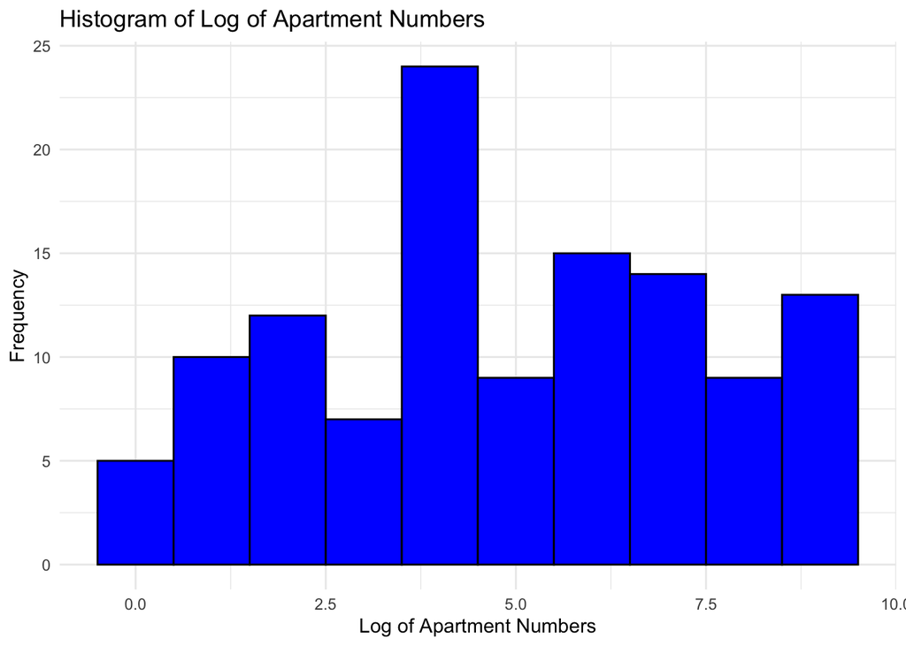

```r
library(ggplot2)
# Use a regular expression to find the last number in the address string
# Extract apartment numbers from the address (assuming the number is at the end of the address)
US_500$apartment_number <- as.numeric(sub(".*?(\\d+)$", "\\1", US_500$address))
# Remove NA values (if any)
apartment_numbers <- na.omit(US_500$apartment_number)

# Apply log transformation to the apartment numbers
log_apartment_numbers <- log(apartment_numbers)

# Create the histogram
library(ggplot2)
ggplot(data = data.frame(log_apartment_numbers), aes(x = log_apartment_numbers)) +
  geom_histogram(binwidth = 1, fill = "blue", color = "black") +
  labs(title = "Histogram of Log of Apartment Numbers",
       x = "Log of Apartment Numbers",
       y = "Frequency") +
  theme_minimal()
```

**e. [Benford’s law](https://en.wikipedia.org/wiki/Benford's_law) is an observation about the distribution of the leading digit of real numerical data. Examine whether the apartment numbers appear to follow Benford’s law. Do you think the apartment numbers would pass as real data?**

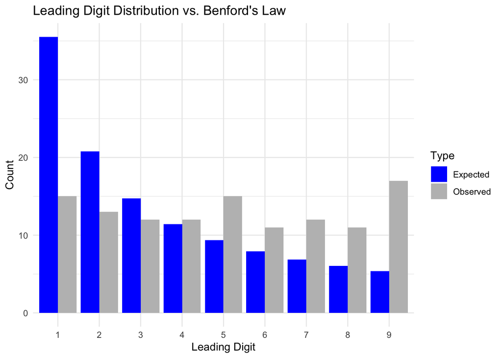

```r
# Extract the leading digit from the apartment numbers
US_500$leading_digit <- as.numeric(sub("^(\\d).*", "\\1", US_500$apartment_number))

# Remove NA values
leading_digits <- na.omit(US_500$leading_digit)

# Count the frequency of each leading digit
digit_counts <- table(leading_digits)

# Calculate the expected distribution according to Benford's Law
benford_probs <- log10((1:9) + 1) - log10(1:9)
benford_counts <- benford_probs * length(leading_digits)

# Create a data frame for plotting
comparison_data <- data.frame(
  Digit = as.integer(names(digit_counts)),
  Observed = as.numeric(digit_counts),
  Expected = benford_counts
)

# Reshape data for ggplot
comparison_data_long <- tidyr::pivot_longer(comparison_data,
                                              cols = c("Observed", "Expected"),
                                              names_to = "Type",
                                              values_to = "Count")

# Create a bar plot to compare observed and expected distributions
ggplot(comparison_data_long, aes(x = factor(Digit), y = Count, fill = Type)) +
  geom_bar(stat = "identity", position = "dodge") +
  labs(title = "Leading Digit Distribution vs. Benford's Law",
       x = "Leading Digit",
       y = "Count") +
  scale_fill_manual(values = c("Observed" = "grey", "Expected" = "blue")) +
  theme_minimal()
```

Benford’s Law states that the leading digits in many naturally occurring datasets are not uniformly distributed, with smaller digits appearing more frequently as leading digits. The bar plot above illustrated a noticeable deviation between the observed (GREY color) and expected frequencies (BLUE color). Specifically, the digit ‘1’ appeared less frequently than expected, while the digits ‘5’ and ‘9’ were overrepresented.

In conclusion, the observed distribution of the leading digits suggests that the apartment numbers in this dataset may not reflect real-world data. This inconsistency implies that the apartment numbers could have been generated through some artificial process rather than occurring naturally.